# Algumas Análises e Explorações COVID-19

Mario O. de Menezes

Brazil

# Introdução

A pandemia do novo coronavirus tomou o mundo de assalto. Notícias em todo o lugar dão conta do rápido alastramento do vírus em todo o mundo, e os seus números são alarmantes.

Para permitir que mais e mais pessoas possam ajudar no combate ao vírus, das mais diversas formas, organizações ao redor do mundo tem disponibilizado dados sobre a evolução da COVID-19 em todo o globo.

Dentre as organizações que disponibilizam dados estão a [European Union Open Data Portal](https://data.europa.eu/euodp/en/home), a [John Hopkins University](https://github.com/CSSEGISandData/2019-nCoV) através de um repositório no GitHub.

Com abundância de dados, me propus a realizar algumas explorações e tabulações destes dados visando entender melhor o cenário mundial.

#### Disclaimer

*Este é um trabalho em andamento; não tem cunho científico e nem pretende que sirva de embasamento para qualquer tomada de decisão. É uma abordagem estritamente pessoal.*

[**HOME**](https://momenezes.github.io/covid19/)

### Bases de Dados

Existem várias bases de dados disponíveis sobre a evolução da COVID-19 no mundo. Dentre estas, estou utilizando três para algumas análises e explorações:

- EU Open Data Portal
- CSSE at Johns Hopkins University
- Kaggle – Coronavirus - Brazil, Coronavirus (COVID-19) - Brazil Dataset (by Raphael Fontes) - tks Raphael :-)

Uma base interessante pela atualização é o Worldometer, mas infelizmente ele só oferece instantâneos, não tem série histórica.

O download e preparação das bases é feito em um notebook separado para não poluir muito aqui. O link é: Preparação dos Dados

# Base de dados do EU Open Data Portal

#### Total de Casos pelos dados da EU Open Data Portal: 14-12-2020

| Casos | Mortes | Letalidade |
| --- | --- | --- |
| 71503614 | 1612833 | 2.26% |

## Brasil vs Itália

Uma mostra dos últimos 20 dias da Itália.

| DateRep | Cases | Deaths | CumCases |
| --- | --- | --- | --- |
| 25-11-2020 | 23227 | 853 | 1455022 |
| 26-11-2020 | 25852 | 722 | 1480874 |
| 27-11-2020 | 29001 | 822 | 1509875 |
| 28-11-2020 | 28342 | 827 | 1538217 |
| 29-11-2020 | 26315 | 686 | 1564532 |
| 30-11-2020 | 20646 | 541 | 1585178 |
| 01-12-2020 | 16376 | 672 | 1601554 |
| 02-12-2020 | 19347 | 785 | 1620901 |
| 03-12-2020 | 20709 | 684 | 1641610 |
| 04-12-2020 | 23219 | 993 | 1664829 |

[output cut: 10 more lines]

O mesmo para o Brasil, últimos 20 dias.

| DateRep | Cases | Deaths | CumCases |
| --- | --- | --- | --- |
| 25-11-2020 | 31100 | 630 | 6118708 |
| 26-11-2020 | 47898 | 654 | 6166606 |
| 27-11-2020 | 37614 | 691 | 6204220 |
| 28-11-2020 | 34130 | 514 | 6238350 |
| 29-11-2020 | 51922 | 587 | 6290272 |
| 30-11-2020 | 24468 | 272 | 6314740 |
| 01-12-2020 | 21138 | 287 | 6335878 |
| 02-12-2020 | 50909 | 697 | 6386787 |
| 03-12-2020 | 49863 | 698 | 6436650 |
| 04-12-2020 | 50434 | 755 | 6487084 |

[output cut: 10 more lines]

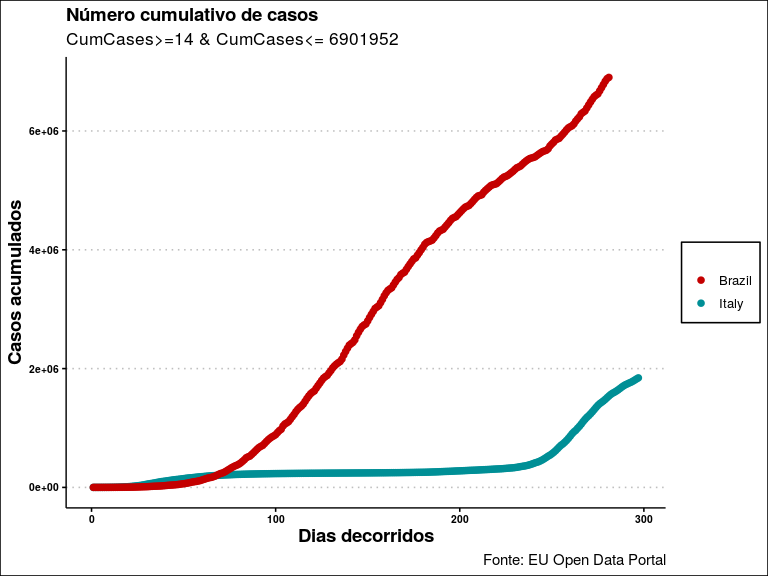

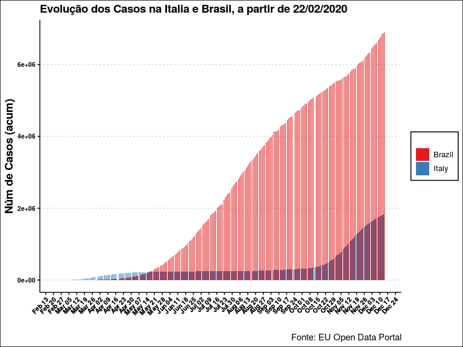

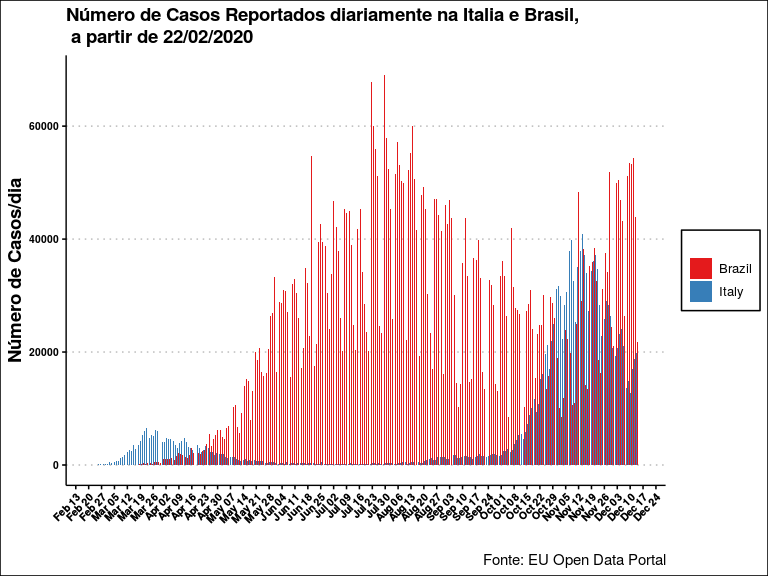

### Alguns gráficos exploratórios com a base EU Open Data Portal

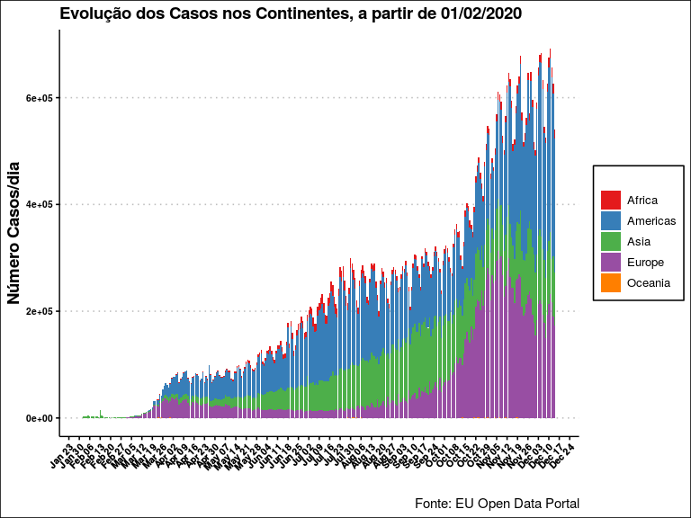

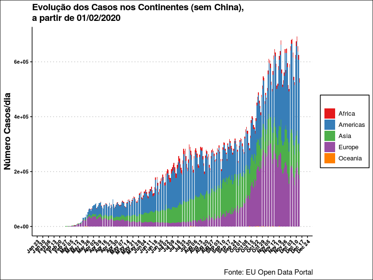

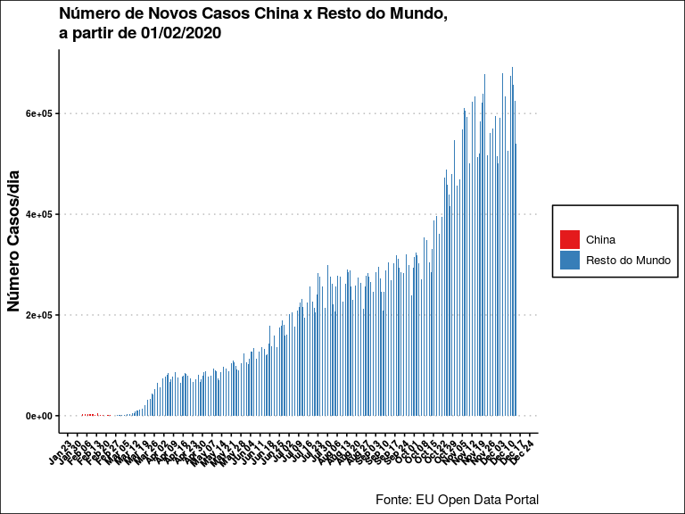

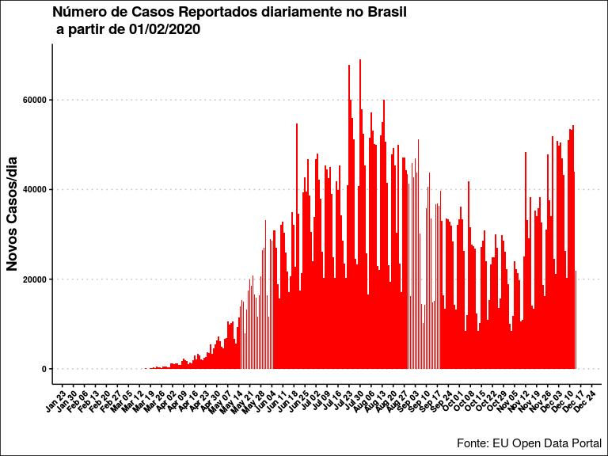

#### Países com mais de 500 casos confirmados: 14-12-2020

| Country | Casos | Mortes |
| --- | --- | --- |
| United States | 16256754 | 299177 |
| India | 9884100 | 143355 |
| Brazil | 6901952 | 181402 |
| Russia | 2653928 | 46941 |
| France | 2376852 | 57911 |
| United Kingdom | 1849403 | 64170 |
| Italy | 1843712 | 64520 |
| Spain | 1730575 | 47624 |
| Argentina | 1498160 | 40766 |
| Colombia | 1425774 | 39053 |

[output cut: 170 more lines]

# Base de dados da John Hopkins University

### Total de Casos pelos dados da John Hopkins University (JHU): 19-09-2022

| Casos Confirmados | Mortos | Recuperados |
| --- | --- | --- |
| 612408336 | 6527907 | 697 |

### Últimos 10 dias para alguns países: 19-09-2022

| DateRep | ConfirmedCases | Deaths | Recovered |
| --- | --- | --- | --- |
| 10-09-2022 | 34898909 | 155508 | 0 |
| 11-09-2022 | 34898909 | 155508 | 0 |
| 12-09-2022 | 34939449 | 155569 | 0 |
| 13-09-2022 | 34985401 | 155633 | 0 |
| 14-09-2022 | 35015024 | 155651 | 0 |
| 15-09-2022 | 35048305 | 155684 | 0 |
| 16-09-2022 | 35076991 | 155712 | 0 |
| 17-09-2022 | 35076991 | 155712 | 0 |
| 18-09-2022 | 35076991 | 155712 | 0 |
| 19-09-2022 | 35138509 | 155783 | 0 |

| DateRep | ConfirmedCases | Deaths | Recovered |
| --- | --- | --- | --- |
| 10-09-2022 | 22035291 | 176204 | 0 |
| 11-09-2022 | 22047192 | 176238 | 0 |
| 12-09-2022 | 22054443 | 176242 | 0 |
| 13-09-2022 | 22077601 | 176335 | 0 |
| 14-09-2022 | 22096450 | 176404 | 0 |
| 15-09-2022 | 22114423 | 176464 | 0 |
| 16-09-2022 | 22131785 | 176508 | 0 |
| 17-09-2022 | 22148935 | 176546 | 0 |
| 18-09-2022 | 22161016 | 176578 | 0 |
| 19-09-2022 | 22169273 | 176609 | 0 |

| DateRep | ConfirmedCases | Deaths | Recovered |
| --- | --- | --- | --- |
| 10-09-2022 | 13367647 | 113130 | 0 |
| 11-09-2022 | 13367647 | 113130 | 0 |
| 12-09-2022 | 13367647 | 113130 | 0 |
| 13-09-2022 | 13374116 | 113279 | 0 |
| 14-09-2022 | 13374116 | 113279 | 0 |
| 15-09-2022 | 13374116 | 113279 | 0 |
| 16-09-2022 | 13384876 | 113725 | 0 |
| 17-09-2022 | 13384876 | 113725 | 0 |
| 18-09-2022 | 13384876 | 113725 | 0 |
| 19-09-2022 | 13384876 | 113725 | 0 |

| DateRep | ConfirmedCases | Deaths | Recovered |
| --- | --- | --- | --- |
| 10-09-2022 | 34516739 | 684813 | 0 |
| 11-09-2022 | 34516739 | 684813 | 0 |
| 12-09-2022 | 34533957 | 684898 | 0 |
| 13-09-2022 | 34544377 | 685002 | 0 |
| 14-09-2022 | 34558902 | 685121 | 0 |
| 15-09-2022 | 34568833 | 685203 | 0 |
| 16-09-2022 | 34568833 | 685203 | 0 |
| 17-09-2022 | 34568833 | 685203 | 0 |
| 18-09-2022 | 34568833 | 685203 | 0 |
| 19-09-2022 | 34592163 | 685424 | 0 |

Para poder estudar o crescimento do número de casos e de mortes, foi adicionada uma coluna com o número de casos de um dia para o outro, já que a base de dados reporta o total de casos em cada dia e não quantos casos foram registrados naquele dia.

### Lista de países com mais de 500 casos, ordenados por número de casos confirmados: 19-09-2022

| País | Casos | Mortes | Recuperados |
| --- | --- | --- | --- |
| United States | 95713363 | 1053840 | 0 |
| India | 44543089 | 528370 | 0 |
| France | 35138509 | 155783 | 0 |
| Brazil | 34592163 | 685424 | 0 |
| Germany | 32740593 | 149079 | 0 |
| South Korea | 24461737 | 27891 | 0 |
| United Kingdom | 23803311 | 207189 | 0 |
| Italy | 22169273 | 176609 | 0 |
| Japan | 20731652 | 43842 | 0 |
| Russia | 20192164 | 378324 | 0 |

[output cut: 188 more lines]

### Alguns gráficos exploratórios com a base do JHU

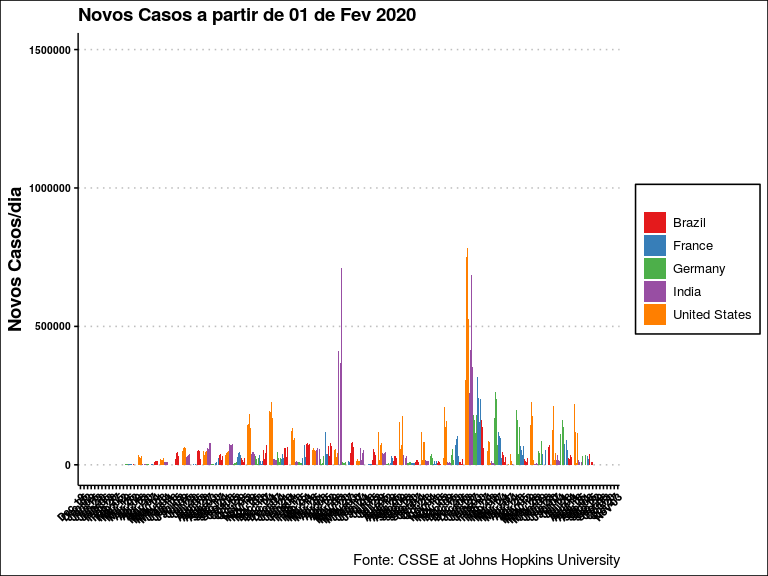

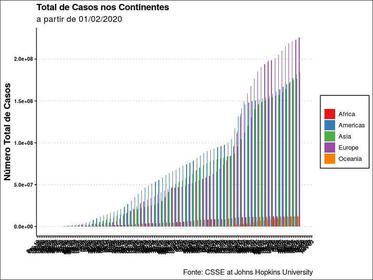

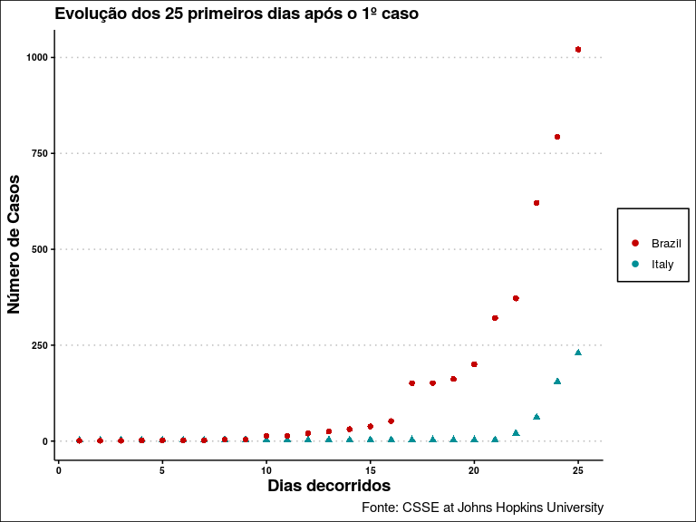

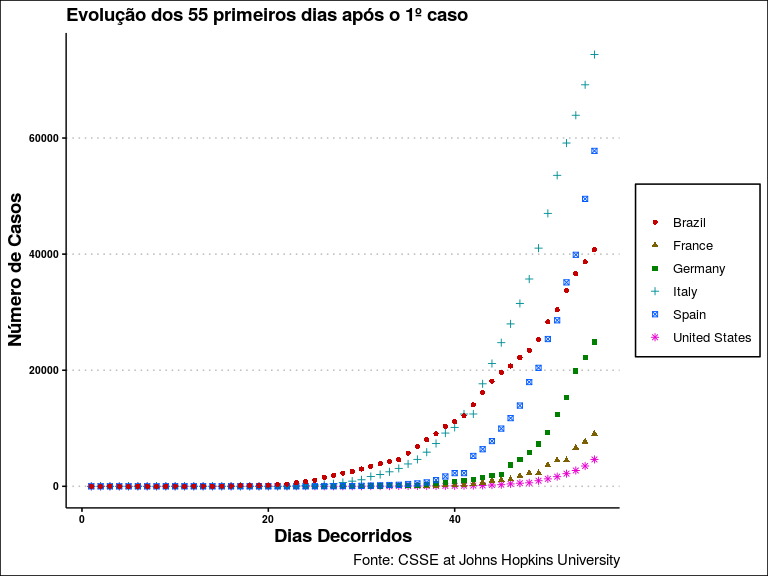

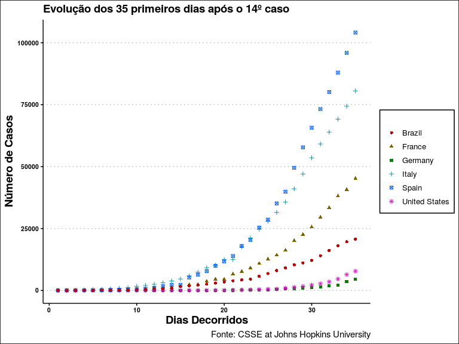

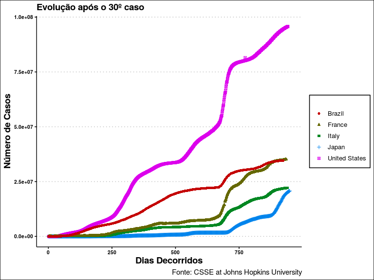

| DateRep | United States | Italy | France | Germany | Spain | Brazil | Chile |
| --- | --- | --- | --- | --- | --- | --- | --- |
| 21-02-2020 | 35 |  |  |  |  |  |  |
| 22-02-2020 | 35 | 62 |  |  |  |  |  |
| 23-02-2020 | 35 | 155 |  |  |  |  |  |
| 24-02-2020 | 53 | 229 |  |  |  |  |  |
| 25-02-2020 | 53 | 322 |  |  |  |  |  |
| 26-02-2020 | 59 | 453 |  |  |  |  |  |
| 27-02-2020 | 60 | 655 | 38 | 46 |  |  |  |
| 28-02-2020 | 62 | 888 | 57 | 48 | 32 |  |  |
| 29-02-2020 | 70 | 1128 | 100 | 79 | 45 |  |  |
| 01-03-2020 | 76 | 1694 | 130 | 130 | 84 |  |  |

[output cut: 932 more lines]

### Calculando a taxa de progressão dia-a-dia: Brasil, Itália, China, USA, França, Alemanha, Espanha

Seguindo a ideia apresentada neste vídeo [Te Explico POR QUÉ estoy PREOCUPADO](https://youtu.be/-PUT0hZiZEw), calculei a taxa de evolução (*chamado de ‘factor’ no vídeo*) A taxa de evolução representada aqui é dada por
$$TxEv = \frac{NumCasos_i - NumCasos_{i-1}}{NumCasos_{i-1}} + 1$$
É uma maneira simples de representar o acréscimo proporcional de um dia para outro.

| DateRep | Brazil | China | France | Germany | Italy | Japan | Spain | United States |
| --- | --- | --- | --- | --- | --- | --- | --- | --- |
| 2020-03-01 | 1.000 | 1.007 | 1.300 | 1.646 | 1.502 | 1.062 | 1.867 | 1.086 |
| 2020-03-02 | 1.000 | 1.003 | 1.469 | 1.223 | 1.202 | 1.070 | 1.429 | 1.329 |
| 2020-03-03 | 1.000 | 1.002 | 1.068 | 1.233 | 1.229 | 1.069 | 1.375 | 1.208 |
| 2020-03-04 | 2.000 | 1.001 | 1.397 | 1.337 | 1.235 | 1.130 | 1.345 | 1.254 |
| 2020-03-05 | 1.000 | 1.002 | 1.323 | 1.840 | 1.249 | 1.088 | 1.167 | 1.444 |
| 2020-03-06 | 3.250 | 1.002 | 1.732 | 1.390 | 1.202 | 1.167 | 1.544 | 1.258 |
| 2020-03-07 | 1.000 | 1.001 | 1.453 | 1.193 | 1.269 | 1.098 | 1.250 | 1.500 |
| 2020-03-08 | 1.538 | 1.001 | 1.187 | 1.302 | 1.254 | 1.089 | 1.346 | 1.288 |
| 2020-03-09 | 1.250 | 1.000 | 1.074 | 1.131 | 1.244 | 1.018 | 1.594 | 1.127 |
| 2020-03-10 | 1.240 | 1.000 | 1.476 | 1.239 | 1.107 | 1.137 | 1.580 | 1.585 |

[output cut: 923 more lines]

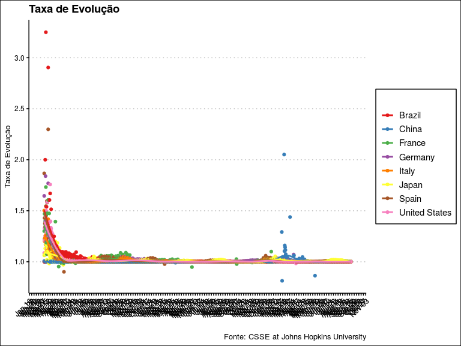

### Gráficos individuais por países: Taxa de evolução e número de novos casos

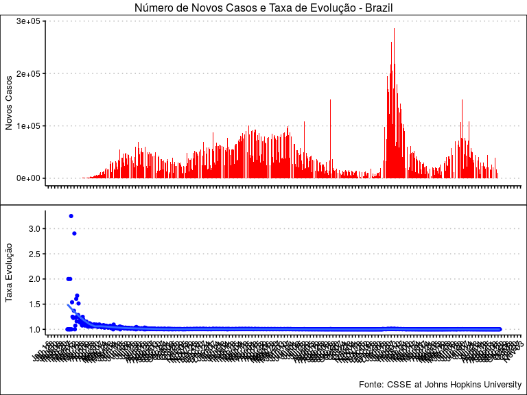

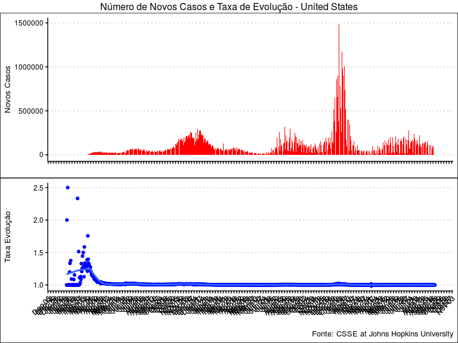

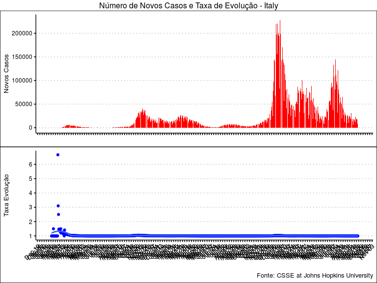

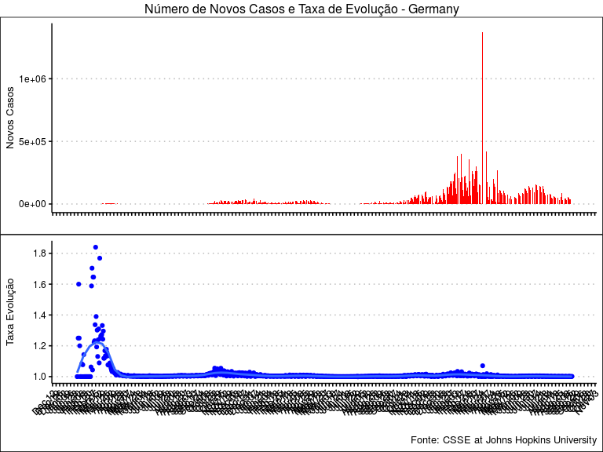

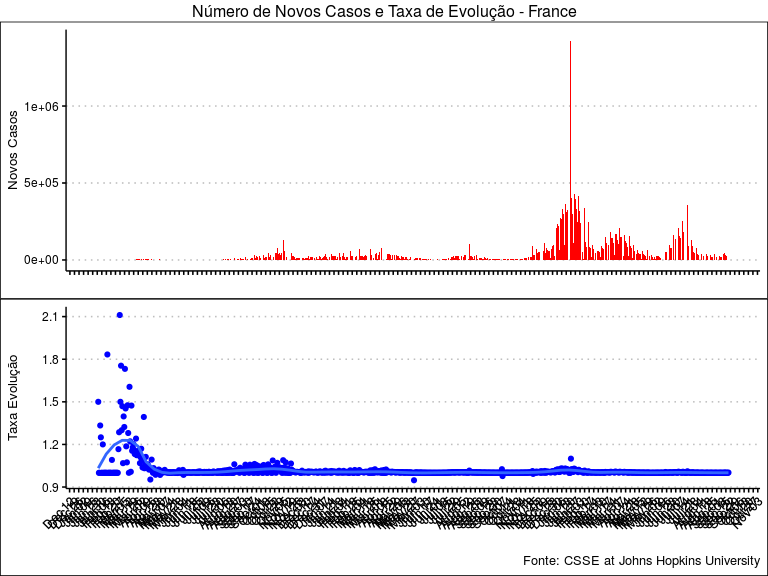

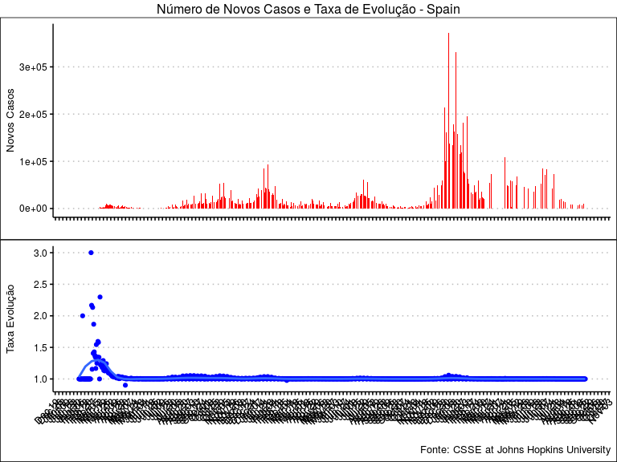

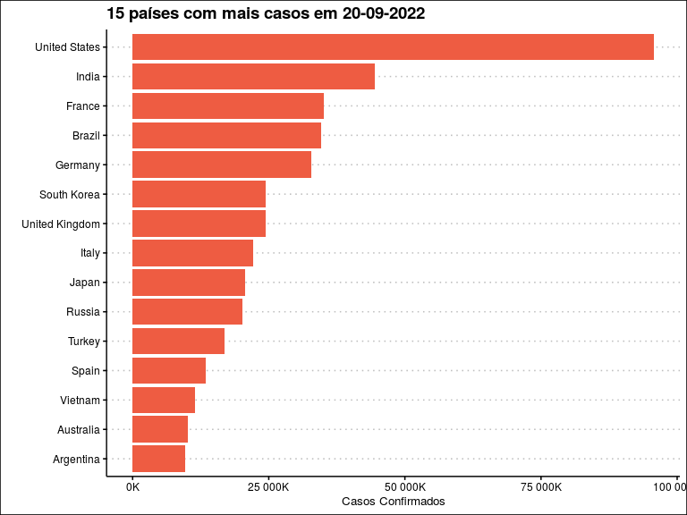

### Casos confirmados *vs* Novos Casos

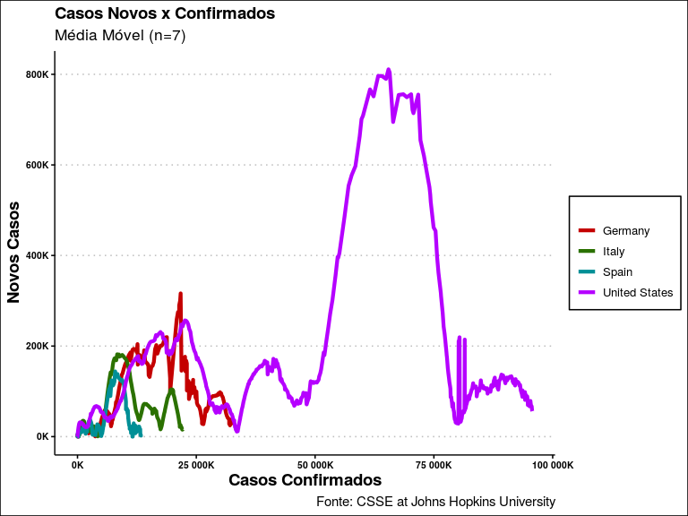

Agora apenas com os países com comportamentos mais parecidos: Itália, Espanha, Alemanha

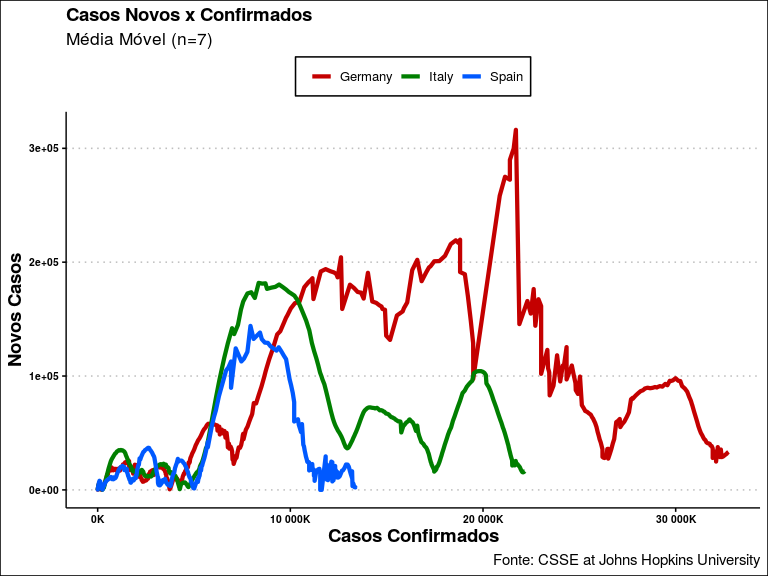

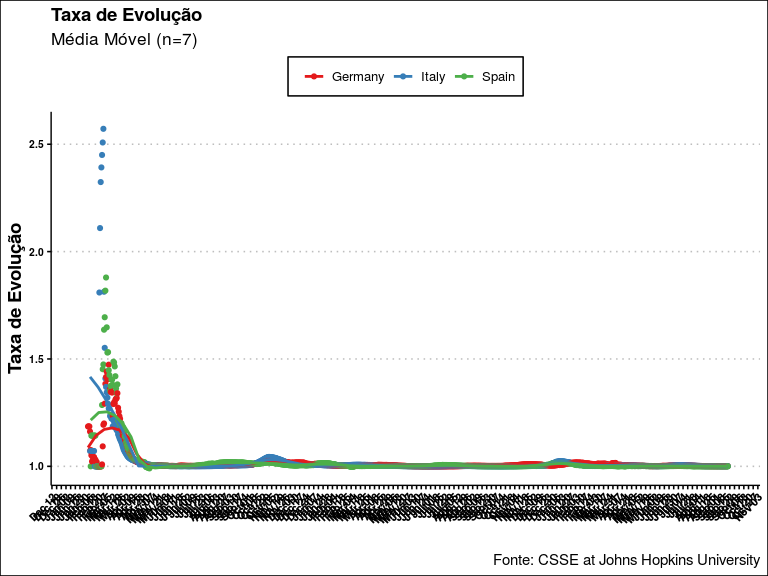

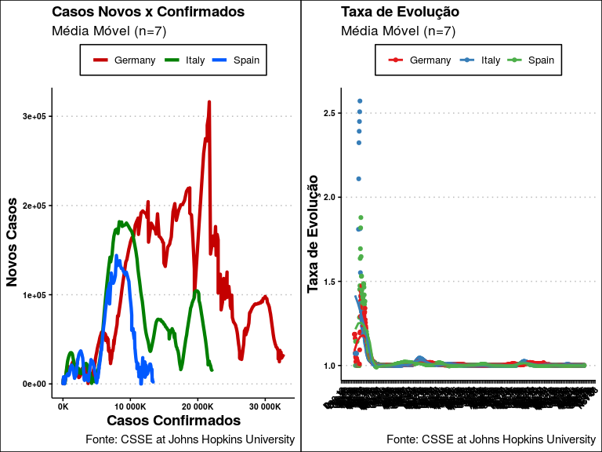

### Casos Confirmados *vs* Número de dias decorridos após 100º caso

Para colocar todos os países no mesmo gráfico, é necessário utilizar uma escala *log*, que comprime a amplitude dos dados, permitindo melhor visualização do comportamento geral.

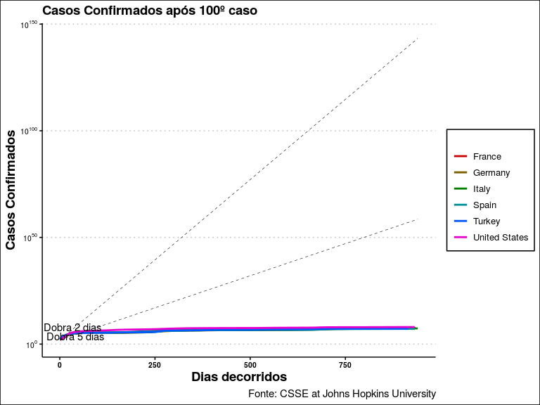

## Países com números de casos semelhantes ao Brasil em 25/03/2020

Em 25 de Março de 2020, os países abaixo tinham número de casos próximos entre si; estabeleci uma faixa, variando de 2304 a 2804 e filtrei os países. Adicionei à lista, que estava fora desta faixa, Portugal.

| Country | ConfirmedCases |
| --- | --- |
| Australia | 2364 |
| Brazil | 2554 |
| Israel | 2369 |
| Sweden | 2526 |
| Turkey | 2433 |
| Portugal | 2995 |

Os gráficos a seguir mostram a evolução dos casos nestes países a partir de pontos diferentes:

- a partir do 1º caso, 55 dias
- a partir do 14º caso, 35 dias
- a partir do 30º caso, até último dado.

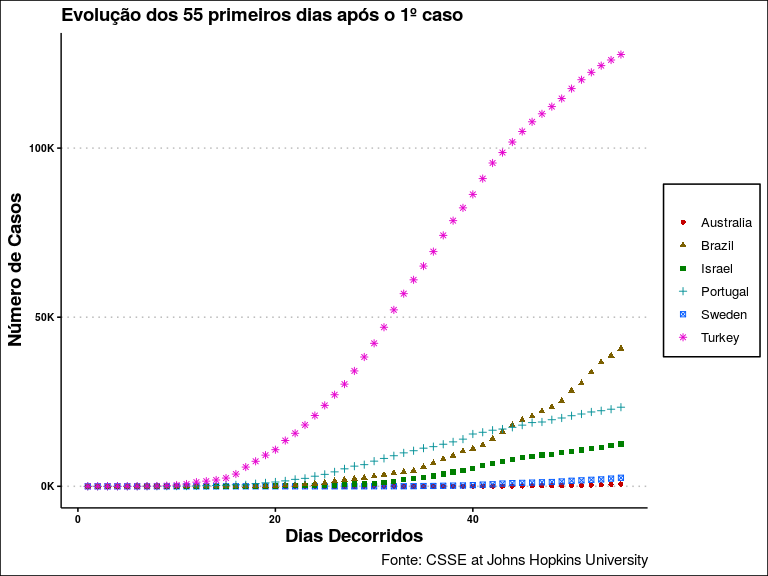

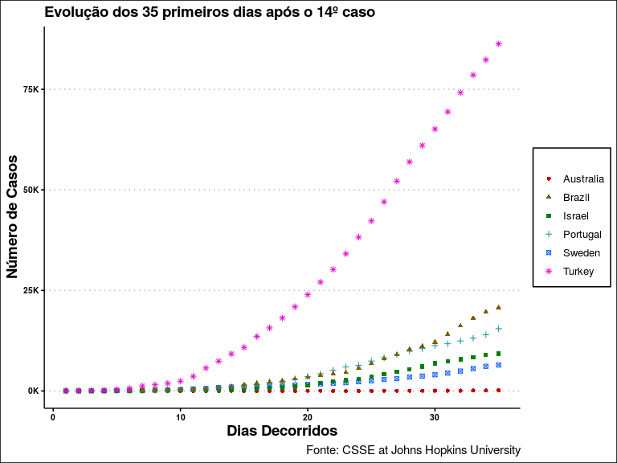

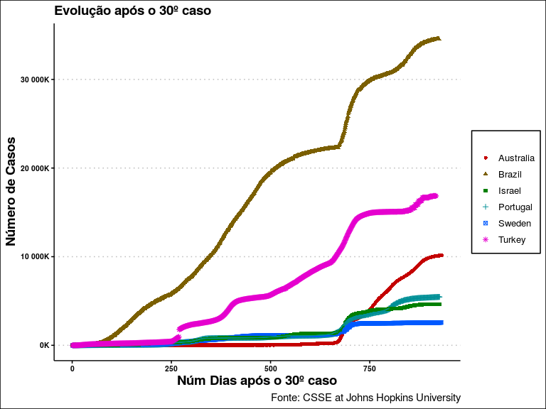

| DateRep | Australia | Sweden | Israel | Portugal | Brazil | Turkey |
| --- | --- | --- | --- | --- | --- | --- |
| 02-03-2020 | 30 |  |  |  |  |  |
| 03-03-2020 | 39 |  |  |  |  |  |
| 04-03-2020 | 52 | 35 |  |  |  |  |
| 05-03-2020 | 55 | 94 |  |  |  |  |
| 06-03-2020 | 60 | 101 |  |  |  |  |
| 07-03-2020 | 63 | 161 |  |  |  |  |
| 08-03-2020 | 76 | 203 | 39 | 30 |  |  |
| 09-03-2020 | 91 | 248 | 39 | 30 |  |  |
| 10-03-2020 | 107 | 355 | 58 | 41 | 31 |  |
| 11-03-2020 | 128 | 500 | 109 | 59 | 38 |  |

[output cut: 922 more lines]

#### Calculando a taxa de progressão dia-a-dia: Brazil, Portugal, Sweden, Turkey, Israel, Australia

| DateRep | Australia | Brazil | Israel | Sweden | Portugal | Turkey |
| --- | --- | --- | --- | --- | --- | --- |
| 2020-03-01 | 1.080 | 1.00 | 1.429 | 1.167 |  |  |
| 2020-03-02 | 1.111 | 1.00 | 1.000 | 1.071 | NA |  |
| 2020-03-03 | 1.300 | 1.00 | 1.200 | 1.400 | 1.000 |  |
| 2020-03-04 | 1.333 | 2.00 | 1.250 | 1.667 | 2.500 |  |
| 2020-03-05 | 1.058 | 1.00 | 1.067 | 2.686 | 1.600 |  |
| 2020-03-06 | 1.091 | 3.25 | 1.312 | 1.074 | 1.625 |  |
| 2020-03-07 | 1.050 | 1.00 | 1.000 | 1.594 | 1.538 |  |
| 2020-03-08 | 1.206 | 1.54 | 1.857 | 1.261 | 1.500 |  |
| 2020-03-09 | 1.197 | 1.25 | 1.000 | 1.222 | 1.000 |  |
| 2020-03-10 | 1.176 | 1.24 | 1.487 | 1.431 | 1.367 |  |

[output cut: 923 more lines]

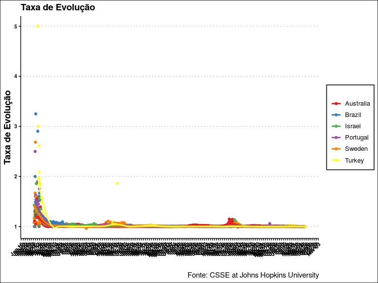

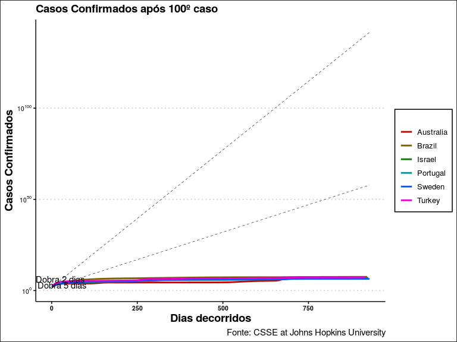

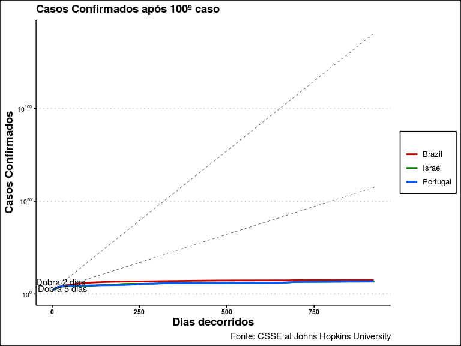